# 03 - Summarising data

In this session we will get to know our three best friends for summarising data: `group_by()`, `summarise()`, and `mutate()`.

# Data

In Session 2, we used a very condensed version of the Global Burden of Disease data. In this module we are going back to a longer one and we will learn how to summarise it ourselves.

```r
source(here::here("healthyr_theme.R"))
load(here::here("global_burden_disease_long.rda"))
```

```r
mydata %>%
    ggplot(aes(x=year, y=deaths_millions, fill=cause))+
    geom_col(colour = "black")

mydata %>%
    filter(year == 1990)
```

# Tidyverse packages: ggplot2, dplyr, tidyr, etc.

Most of the functions introduced in this session come from the tidyverse family (http://tidyverse.org/), rather than Base R. Including `library(tidyverse)` in your script loads a list of packages: ggplot2, dplyr, tidyr, forcats, etc.

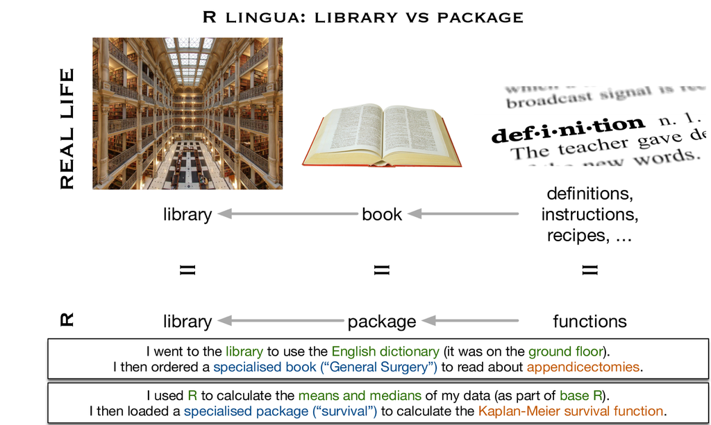

```r
library(tidyverse)
```

# Basic functions for summarising data

You can always pick a column and ask R to give you the `sum()`, `mean()`, `min()`, `max()`, etc. for it:

```r
mydata$deaths_millions %>% sum()
mydata$deaths_millions %>% mean()
```

But if you want to get the total number of deaths for each `year` (or `cause`, or `sex`, whichever grouping variables you have in your dataset) you can use `group_by()` and `summarise()` that make subgroup analysis very convenient and efficient.

# Subgroup analysis: `group_by()` and `summarise()`

The `group_by()` function tells R that you are about to perform subgroup analysis on your data. It retains information about your groupings and calculations are applied on each group separately. To go back to summarising the whole dataset again use `ungroup()`. Note that `summarise()` is different to the `summary()` function we used in Session 2.

With `summarise()`, we can calculate the total number of deaths per year:

```r
summary_data1 =
  mydata %>%
  group_by(year) %>%
  summarise(total_per_year = sum(deaths_millions))
summary_data1

summary_data2 =
  mydata %>%
  group_by(year, cause) %>%
  summarise(total_per_cause = sum(deaths_millions))
summary_data2
```

- `summary_data1` includes the total number of deaths per year.
- `summary_data2` includes the number of deaths per cause per year.

## Exercise 1

Compare the number of rows (observations) and number of columns (variables) of:

- `mydata`,
- `summary_data1`, and
- `summary_data2` (in the Environment tab).

Notice that: * `summary_data2` has exactly 3 times as many rows as `summary_data1`. Why? * `mydata` has 5 variables, whereas the summarised tibbles have 2 and 3. Which variables got dropped? Why?

## Exercise 2

For each cause, calculate its percentage to total deaths in each year.

Hint: Use `full_join()` on `summary_data1` and `summary_data2`.

```r
# Exercise 2 - your R code:
```

# `mutate()`

Mutate works similarly to `summarise()` (as in it respects groupings set with `group_by()`), but it adds a new column into the original data. `summarise()`, on the other hand, condenses the data into a minimal table that only includes the variables specifically asked for.

## Exercise 3

Investigate these examples to learn how `summarise()` and `mutate()` differ.

```r
summarise_example = mydata %>%
    summarise(total_deaths = sum(deaths_millions))
summarise_example

mutate_example = mydata %>%
    mutate(total_deaths = sum(deaths_millions))
mutate_example
```

You should see that `mutate()` adds the same number total number (309.4174) to every line in the tibble.

## Exercise 4 (optional)

Based on what we just observed on how `mutate()` adds a value to each row, can you think of a way to redo **Exercise 2** without using a join? Hint: instead of creating `summary_data1` (total deaths per year) as a separate tibble which we then join with `summary_data2` (total deaths for all causes per year), we can use `mutate()` to add total death per year to each row.

```r
# Exercise 4 - your R code:
```

# Wide vs long: `spread()` and `gather()`

## Wide format

Although having data in the long format is very convenient for R, for publication tables, it makes sense to spread some of the values out into columns:

```r
alldata = full_join(summary_data1, summary_data2)

alldata %>%
  mutate(percentage = 100*total_per_cause/total_per_year) %>%
    mutate(percentage = paste0(round(percentage, 2), "%")) %>% # round and add % label
    select(year, cause, percentage) %>% #only select vars you want in table
    spread(cause, percentage)
```

## Exercise 5

Calculate the percentage of male and female deaths for each year. Spread it to a human readable form:

Hints:

- create `summary_data3` that includes a variable called `total_per_sex`
- join `summary_data1` and `summary_data3` into a new tibble
- calculate the percentage of `total_per_sex` to `total_per_year`
- round, add % labels
- spread
- save your object as `result_spread`

Solution:

```r
# Exercise 3.5 - your R code:
```

## Long format

The opposite of `spread()` is `gather()`:

- The first argument is a name for the column that will include columns gathered from the wide columns (in this example, `Male` and `Female` are gathered into `sex`).
- The second argument is a name for the column that will include the values from the wide-format columns (the values from `Male` and `Female` are gathered into `percentage`).
- Any columns that already are condensed (e.g. year was in one column, not spread out like in the pre-course example) must be included with a negative (i.e. -year).

```r
# Result from above
mydata %>%
    group_by(year) %>%
    summarise(total_per_year = sum(deaths_millions)) ->
    summary_data1

mydata %>%
    group_by(year, sex) %>%
    summarise(total_per_sex = sum(deaths_millions)) ->
    summary_data3

alldata = full_join(summary_data1, summary_data3)

result_spread = alldata %>%
  mutate(percentage = round(100*total_per_sex/total_per_year, 0)) %>%
  mutate(percentage = paste0(percentage, "%")) %>%
  select(year, sex, percentage) %>%
  spread(sex, percentage)

result_spread
```

```r
result_spread %>%
  gather(sex, percentage, -year)
```

## Exercise 6

Test what happens when you

- Change the order of sex and percentage:

```r
result_spread %>%
  gather(percentage, sex, -year)
```

Turns out in the above example, `percentage` and `sex` were just label you assigned to the gathered columns. It could be anything, e.g.:

```r
result_spread %>%
  gather(`look-I-gathered-sex`, `values-Are-Here`, -year)
```

- What happens if we omit `-year`:

```r
result_spread %>%
  gather(sex, percentage)
```

`-year` was telling R we don’t want the year column to be gathered together with Male and Female, we want to keep it as it is.

# Sorting: `arrange()`

To reorder data ascendingly or descendingly, use `arrange()`:

```r
mydata %>%
    group_by(year) %>%
    summarise(total = sum(deaths_millions))  %>%
    arrange(-year) # reorder after summarise()
```

## Exercise 7

This exercise includes multiple steps, combining all of the above.

- Load `"global_burden_disease_long.rda"`.
- Calculate the total number of deaths in Developed and Developing countries. Hint: use `group_by(location)` and `summarise( Include new column name = sum() here)`.
- Calculate the total number of deaths in Developed and Developing countries and for men and women. Hint: this is as easy as adding `, sex` to `group_by()`.
- Filter for 1990.
- `spread()` the `location` column.

```r
library(tidyverse)
load(here::here("global_burden_disease_long.rda"))

# Exercise 3.9 - your R code:
```

## Export object or table as a spreadsheet.

To save as a csv file use `write_csv()`:

```r
write_csv(result_spread, "gbd_genders_summarised.csv")
```

You can open a csv file with Excel and copy the table into Word or PowerPoint for presenting.

# Solutions

## Exercise 2 solution

```r
alldata = full_join(summary_data1, summary_data2) %>%
  mutate(percentage = 100*total_per_cause/total_per_year)
```

## Exercise 4 solution

```r
alldata = mydata %>%
    group_by(year, cause) %>%
    summarise(total_per_cause = sum(deaths_millions)) %>%
    group_by(year) %>%
    mutate(total_per_year = sum(total_per_cause)) %>%
    mutate(percentage = 100*total_per_cause/total_per_year)
alldata
```

## Exercise 5 solution

```r
mydata %>%
    group_by(year) %>%
    summarise(total_per_year = sum(deaths_millions)) ->
    summary_data1

mydata %>%
    group_by(year, sex) %>%
    summarise(total_per_sex = sum(deaths_millions)) ->
    summary_data3

alldata = full_join(summary_data1, summary_data3)

result_spread = alldata %>%
  mutate(percentage = round(100*total_per_sex/total_per_year, 0)) %>%
  mutate(percentage = paste0(percentage, "%")) %>%
  select(year, sex, percentage) %>%
  spread(sex, percentage)

result_spread
```

## Exercise 7 solution

```r
library(tidyverse)
load(here::here("global_burden_disease_long.rda"))

mydata %>%
  filter(year == 1990) %>%
  group_by(location, sex) %>%
  summarise(total_deaths = sum(deaths_millions)) %>%
  spread(location, total_deaths)
```